# Seminário - Estatística Multivaridada Computacional

# Estatística Multivaridada Computacional: Teresina - Piauí

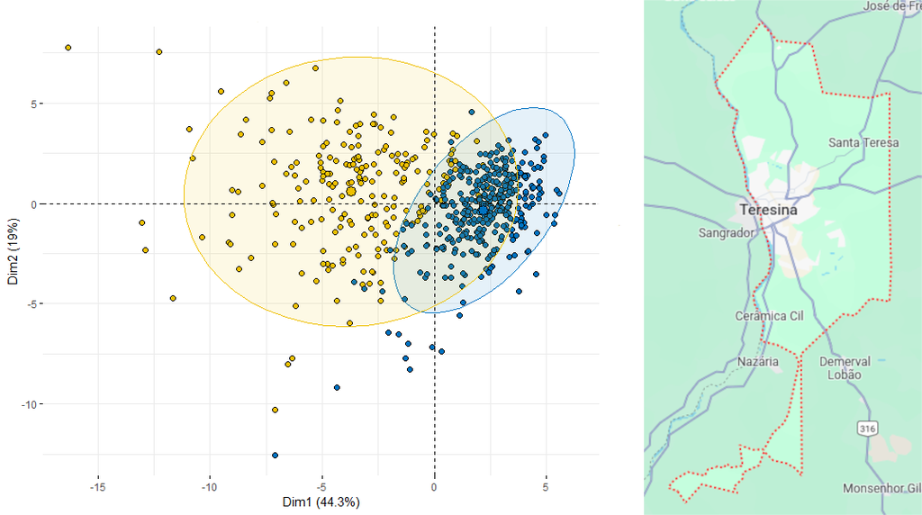

Gabriel Augusto Narciso Barreiros  
Adriano José de Barros  
Nelson Rios

https://github.com/Gabrielj96/Trabalho-R-UFMG-Multivariada

# 0. Bibliotecas e configurações

```r
library(readr)
library(dplyr)
library(FactoMineR)
library(factoextra)
library(corrplot)
library(ggplot2)
library(tidyverse)
library(ggcorrplot)

source("_src/src.R")

library(ggspatial)
#library(ggsn)
library(raster)
#library(rgdal)
library(sf)
library(sp)
library(GGally)
library(stats)
library(maps)
library(psych)

set.seed(111)
options(scipen = 999)

df_teresina = read.csv("SES_Teresina.csv")
```

# 1. Análise Descritiva

## Tamanho populacional

Cidades maiores tendem a ser mais heterogêneas do que cidades menores. Isso significa que as análises PCA realizadas em cidades maiores são mais propensas a identificar padrões complexos e não lineares.

Seguindo essa lógica, talvez, Teresina padrão mais simples como menor variância, menores correlações e menor multicolinearidade facilitando a interpretação dos dados.

```r
df_teresina$ID = df_teresina$area_de_ponderacao %% 100
sum(df_teresina$N)
```

```
[1] 224188
```

```r
subset(df_teresina[order(df_teresina$N), ], select = c('ID', 'N'))
```

|  | ID | N |
| --- | --- | --- |
| 3 | 3 | 8094 |
| 8 | 8 | 8279 |
| 12 | 12 | 8381 |
| 2 | 2 | 8529 |
| 1 | 1 | 8581 |
| 4 | 4 | 8606 |
| 9 | 9 | 8610 |
| 13 | 13 | 8803 |
| 14 | 14 | 9221 |
| 10 | 10 | 9407 |

[output cut: 6 more lines]

## Vetor de médias

### Saneamento

Analisando as variáveis de saneamento percebemos que a cidade tem um bom sistema de água encanada, atingindo um total de 99% de encaneamento de água e não ficando abaixo de 95%.

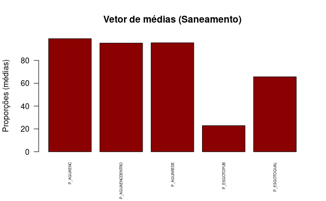

```r
lab.corr_saneamento = c('P_AGUAENC', 'P_AGUAENCDENTRO', 'P_AGUAREDE', 'P_ESGOTOPUB', 'P_ESGOTOQUAL')
lab.corr_moradia = c('P_MATPAREDES', 'P_OVERCROWDING')
lab.corr_emprego = c('P_DESEMP', 'P_FORTRAB')
lab.corr_educacao = c('P_ENSFUND', 'P_ENSMED', 'P_ENSSUP', 'P_FREQESCOLA')

lab.corr = c('P_AGUAENC', 'P_AGUAENCDENTRO', 'P_AGUAREDE', 'P_ESGOTOPUB', 'P_ESGOTOQUAL',
             'P_MATPAREDES', 'P_OVERCROWDING',
             'P_DESEMP', 'P_FORTRAB',
             'P_ENSFUND', 'P_ENSMED', 'P_ENSSUP', 'P_FREQESCOLA')

saneamento = data.frame(as.matrix(colMeans(df_teresina[, lab.corr_saneamento]), 2))

barplot(saneamento$as.matrix.colMeans.df_teresina...lab.corr_saneamento....2.,
main = "Vetor de médias (Saneamento)",
ylab = "Proporções (médias)",
names.arg = row.names(saneamento),
col = "darkred",
las=2,
cex.names=0.45)
```

### Moradia

Analisando as variáveis de moradia é perceptível que a cidade não tem muitos problemas com isso. 95% da população tem algum tipo de moradia e apenas 5% com mais de 3 pessoas no lar.

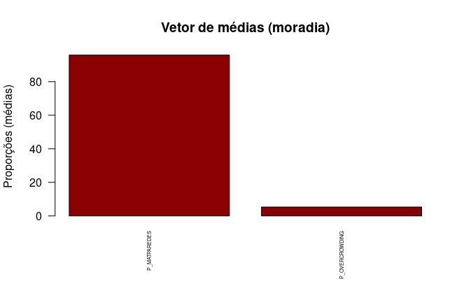

```r
moradia = data.frame(as.matrix(colMeans(df_teresina[, lab.corr_moradia]), 2))

barplot(moradia$as.matrix.colMeans.df_teresina...lab.corr_moradia....2.,
main = "Vetor de médias (moradia)",
ylab = "Proporções (médias)",
names.arg = row.names(moradia),
col = "darkred",
las=2,
cex.names=0.45)
```

### Emprego

Considerando que 7% de desemprego é considerado pleno emprego no Brasil, Teresina com 9% ainda tem um pouco a melhorar.

De acordo com a Organização Internacional do Trabalho (OIT), uma taxa de participação da força de trabalho de 60% ou mais é considerada elevada. Seguindo esse parâmetro Teresina está acima da média com 65%.

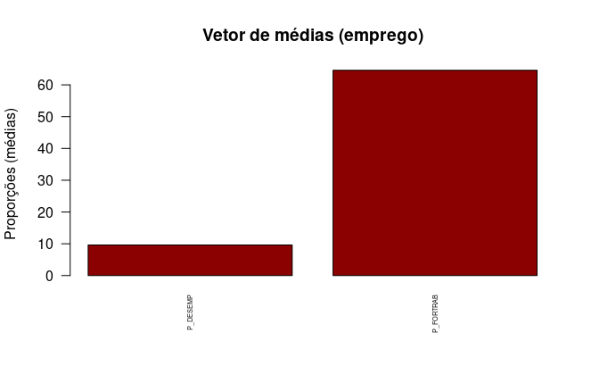

```r
emprego = data.frame(as.matrix(colMeans(df_teresina[, lab.corr_emprego]), 2))

barplot(emprego$as.matrix.colMeans.df_teresina...lab.corr_emprego....2.,
main = "Vetor de médias (emprego)",
ylab = "Proporções (médias)",
names.arg = row.names(emprego),
col = "darkred",
las=2,
cex.names=0.45)
```

### Educação

A cidade tem boa parte da população frequentando a escola (89%), mas essa taxa cai consideravelmente ao aumentar o nível de escolaridade, chegando a 15% no ensino superior. O que da espaço para políticas públicas para a educação.

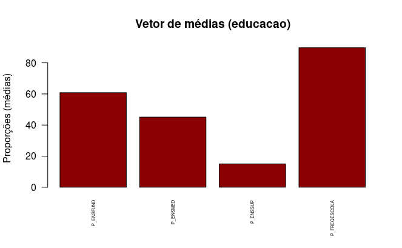

```r
educacao = data.frame(as.matrix(colMeans(df_teresina[, lab.corr_educacao]), 2))

barplot(educacao$as.matrix.colMeans.df_teresina...lab.corr_educacao....2.,
main = "Vetor de médias (educacao)",
ylab = "Proporções (médias)",
names.arg = row.names(educacao),
col = "darkred",
las=2,
cex.names=0.45)
```

## Matriz de correlação

### Educação vs Overcrowding = Correlação Negativa

Quanto menor a educação, maior o número de residências com superlotação.

### Overcrowding vs Material Paredes = Correlação Negativa

Quanto maior o número de residências com superlotação, menor o número de domicílios com paredes feitas de materiais duráveis.

### Educação vs Material Paredes = Correlação Positiva

Quanto maior a educação, maior o número de residências com paredes feitas de materiais duráveis.

### Educação vs Esgoto = Correlação Positiva

Quanto maior a educação, maior o acesso a esgoto.

### Material Paredes vs Residência Encanada = Correlação Positiva

Quanto mais residências com paredes de materiais duráveis, mais residências encanadas.

### Educação vs Residência Encanada = Correlação Positiva

Quanto maior a educação, mais residências encanadas.

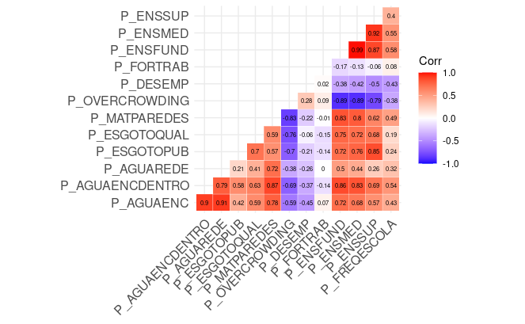

```r
ggcorrplot(cor(df_teresina[, lab.corr]), type = "lower", outline.color = "white",
           lab = TRUE, lab_size = 2)
```

# 2. Análise Qualitativa PCA

```r
df_teresina_scaled = scale(subset(df_teresina, select = -c(UF, municipality, code, ID,
                                                           area_de_ponderacao, N)))
PCA = princomp(df_teresina_scaled)
summary(PCA)
```

```
Importance of components:
                          Comp.1    Comp.2     Comp.3     Comp.4     Comp.5     Comp.6     Comp.7     Comp.8      Comp.9     Comp.10     Comp.11      Comp.12       Comp.13
Standard deviation     2.6987995 1.2095882 1.05079758 0.94833494 0.78426232 0.55541053 0.52690299 0.38998252 0.194472377 0.153693768 0.127856020 0.0750477266 0.02608990087
Proportion of Variance 0.5976221 0.1200495 0.09059902 0.07379193 0.05046707 0.02531125 0.02277963 0.01247888 0.003103139 0.001938197 0.001341306 0.0004621261 0.00005585091
Cumulative Proportion  0.5976221 0.7176716 0.80827062 0.88206255 0.93252962 0.95784087 0.98062050 0.99309938 0.996202521 0.998140717 0.999482023 0.9999441491 1.00000000000
```

O primeiro componente explica 59.8% da variância total, enquanto o segundo 12% e o terceiro 9.1%.

E segundo a regra de Kaiser os primeiros 3 componentes, 81% da variação, podem precisamente representar os dados.

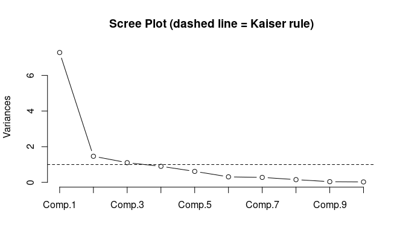

```r
screeplot(PCA, main = 'Scree Plot (dashed line = Kaiser rule)', type = 'l')
abline(h = 1, lty = 2)
```

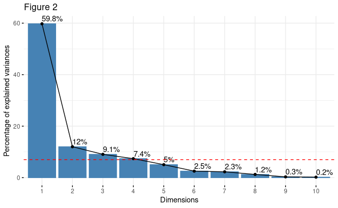

```r
fviz_eig(PCA,
         addlabels = TRUE,
         main="Figure 2") +
         geom_hline(yintercept=7,
         linetype="dashed",
         color = "red")
```

### Proximidade

As variáveis com maior proximidade são os educação e acesso a sistema de esgoto, ou seja, o acesso a educação está relacionada com acesso à algum tipo de sistema de esgoto na residência.

### Distância

As variáveis com maior distância são superlotação e educação, ou seja, o acesso a educação está inversamente relacionada com a superlotação nas residências.

Também percebemos a distância entre a taxa de desemprego, encanamento e frequência escolar. O aumento da taxa de desemprego está relacionada negativamente com esses problemas sociais.

### Distância da Origem e Coloração

Com base na distância da variável em relação ao centro do gráfico percebemos que as variáveis mais bem representadas por esses componentes principais são: educação e saneamento.

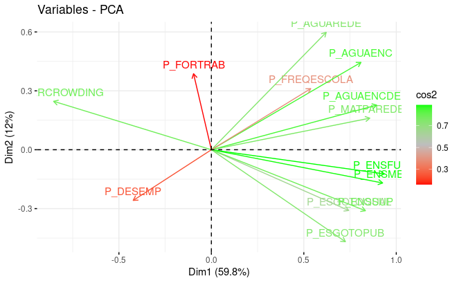

```r
fviz_pca_var(PCA, col.var = "cos2", gradient.cols = c("red", "grey", "green"))
```

# 3. Análise Qualitativa EFA

```r
df_teresina_efa = subset(df_teresina, select = -c(UF, municipality, code, ID,
                                                           area_de_ponderacao, N))
```

### Critério de Kaiser–Meyer–Olkin

Um número baixo significa que as variáveis analisadas não apresentam correlações fortes o suficiente para serem agrupadas em fatores, 0.5 é um valor aceitável, porém não tão alto.

```r
KMO(df_teresina_efa)
```

```
Kaiser-Meyer-Olkin factor adequacy
Call: KMO(r = df_teresina_efa)
Overall MSA =  0.55
MSA for each item =
      P_AGUAENC P_AGUAENCDENTRO      P_AGUAREDE     P_ESGOTOPUB    P_ESGOTOQUAL    P_MATPAREDES  P_OVERCROWDING        P_DESEMP       P_ENSFUND        P_ENSMED        P_ENSSUP       P_FORTRAB    P_FREQESCOLA
           0.48            0.63            0.48            0.70            0.64            0.81            0.73            0.22            0.59            0.60            0.69            0.03            0.32
```

### Scree Plots

```
Parallel analysis suggests that the number of factors =  1  and the number of components =  NA
```

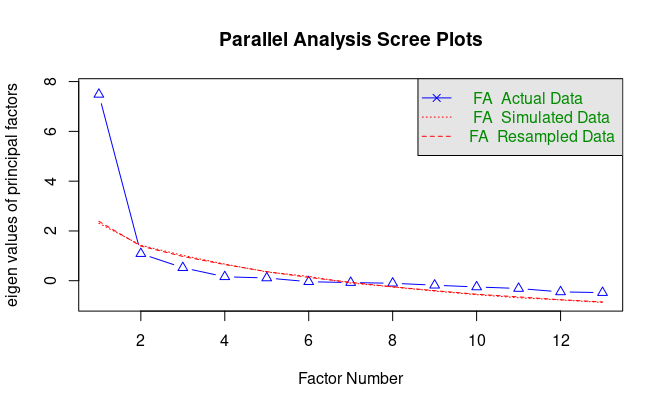

```r
fa.parallel(df_teresina_efa, fa="fa")
```

### Análise Fatorial

Já 5 fatores explicam 83% da variação total, porém o p-valor fica um tanto alto. Neste caso podemos aceitar 72% de explicação da variação total e um p-valor menor com 3 fatores.

```r
EFA = factanal(df_teresina_efa, factors = 5, scores = 'regression', nstart = 100)
EFA
```

```
Call:
factanal(x = df_teresina_efa, factors = 5, scores = "regression",     nstart = 100)

Uniquenesses:
      P_AGUAENC P_AGUAENCDENTRO      P_AGUAREDE     P_ESGOTOPUB    P_ESGOTOQUAL    P_MATPAREDES  P_OVERCROWDING        P_DESEMP       P_ENSFUND        P_ENSMED        P_ENSSUP       P_FORTRAB    P_FREQESCOLA
          0.005           0.075           0.040           0.188           0.005           0.005           0.093           0.395           0.005           0.005           0.005           0.829           0.500

Loadings:
                Factor1 Factor2 Factor3 Factor4 Factor5
P_AGUAENC        0.345   0.882   0.310
P_AGUAENCDENTRO  0.484   0.727   0.293   0.255   0.102
P_AGUAREDE               0.961   0.100          -0.106
P_ESGOTOPUB      0.885           0.136
P_ESGOTOQUAL     0.794   0.434  -0.128  -0.266   0.298
P_MATPAREDES     0.560   0.648           0.511
P_OVERCROWDING  -0.810  -0.336          -0.318  -0.193
P_DESEMP        -0.154  -0.181  -0.729           0.115
P_ENSFUND        0.724   0.430   0.292   0.298   0.335
P_ENSMED         0.767   0.353   0.346   0.294   0.278
P_ENSSUP         0.866   0.137   0.463
P_FORTRAB                                       -0.400
P_FREQESCOLA     0.163   0.291   0.353   0.423   0.291

               Factor1 Factor2 Factor3 Factor4 Factor5
SS loadings      4.661   3.406   1.306   0.878   0.601
Proportion Var   0.359   0.262   0.100   0.068   0.046
Cumulative Var   0.359   0.621   0.721   0.789   0.835

Test of the hypothesis that 5 factors are sufficient.
The chi square statistic is 26.56 on 23 degrees of freedom.
The p-value is 0.275
```

```r
EFA = factanal(df_teresina_efa, factors = 3, scores = 'regression', nstart = 100)
EFA4 = factanal(df_teresina_efa, factors = 4, scores = 'regression', nstart = 100)
EFA4$PVAL
```

```
objective
0.2379858
```

```r
EFA$PVAL
```

```
objective
0.1858346
```

### Gráfico de Análise Fatorial

Podemos interpretar os fatores da seguinte forma:

- **Fator 1:** Educação, saneamento, moradia e emprego
- **Fator 2:** Saneamento, moradia
- **Fator 3:** Educação e emprego

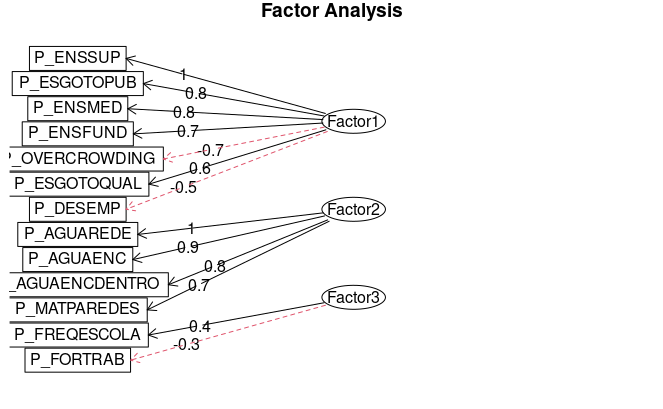

```r
fa.diagram(EFA$loadings)
```